# Comparison of EdgeR and Voom+limma on zero inflated low counts data

# Comparison of DE analysis results

Import libraries and data.

```r
library(edgeR)
library(DESeq2)
library(ggplot2)
library(knitr)
load("data.Rdata")
interests <- c("NC_001716.2_region_1_153080__ID=id0", "NC_001664.2_region_1_159322__ID=id0")
```

Data variables include, `data.Rdata` contains four variables - `virMat` (read counts), `fullReadsPerSample` (library size), `comparison_annot` (condition and covariates), and `interests`.

```r
ls()
```

```
## [1] "comparison_annot"   "fullReadsPerSample" "interests"
## [4] "virMat"
```

A summary of the condition and covariates used in this analysis.

As the follow, `data.Rdata` contains four variables - `virMat` (read counts), `fullReadsPerSample` (library size), `comparison_annot` (condition and covariates), and `interests`.

```r
ls()
```

```
## [1] "comparison_annot"   "fullReadsPerSample" "interests"
## [4] "virMat"
```

This shows us a summary of the condition and covariates used in this analysis.

```r
summary(comparison_annot)
```

```
##      status        RIN              AOD         Race   Sex
##  Control:29   Min.   : 6.000   Min.   : 61.00   B:15   F:72
##  Case   :67   1st Qu.: 6.375   1st Qu.: 79.00   H: 4   M:24
##               Median : 6.800   Median : 86.00   W:77
##               Mean   : 6.883   Mean   : 85.65
##               3rd Qu.: 7.300   3rd Qu.: 93.25
##               Max.   :10.000   Max.   :108.00
##
##        Batch         PMI
##  S114_B394:34   Min.   :  75.0
##  S113_B355:22   1st Qu.: 188.8
##  K75r_C014:17   Median : 300.0
##  E007_C014: 8   Mean   : 382.9
##  S113_B394: 7   3rd Qu.: 426.2
##  S112_B394: 4   Max.   :1410.0
##  (Other)  : 4
```

The following plot shows the count distributions of viruses in questions.

The following plot shows the count distributions of our interests.

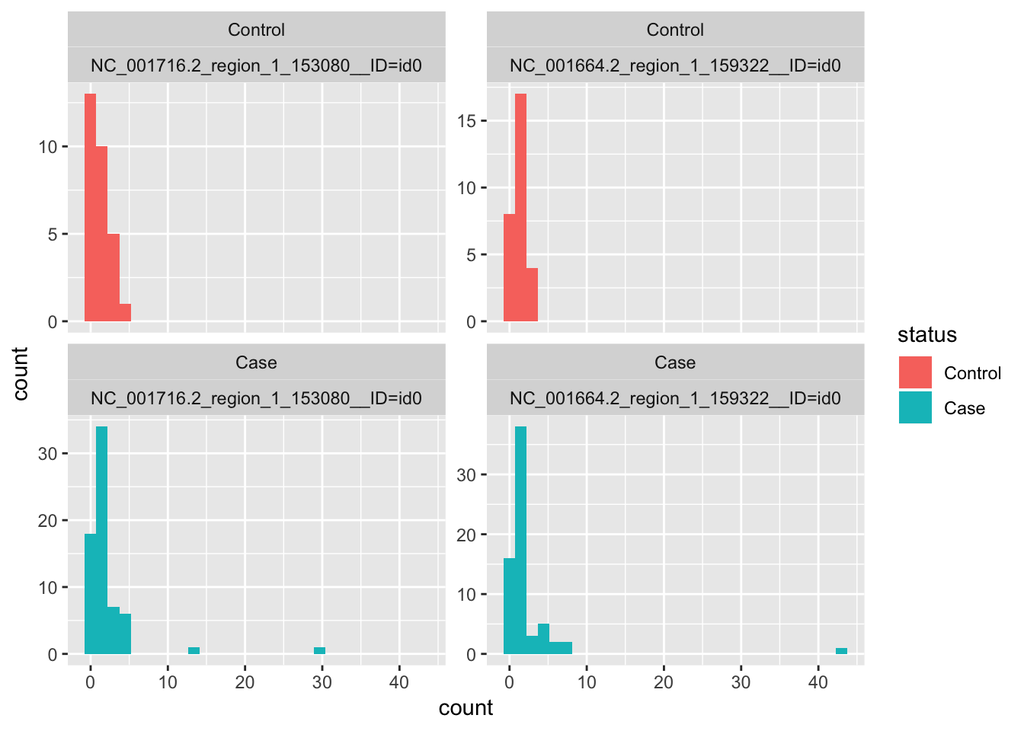

```r
df_int <-
  rbind(
    data.frame(id = interests[1], count = unlist(virMat[interests[1],]), status = comparison_annot$status),
    data.frame(id = interests[2], count = unlist(virMat[interests[2],]), status = comparison_annot$status)
  )
ggplot(df_int, aes(x=count)) +
  geom_histogram(aes(fill=status)) + facet_wrap(status~id, scales = "free_y")
```

The following function produces a result of DE using `voom + Limma`.

The following function produces a result of DE using `voom`.

```r
run_voom <- function(virMat, fullReadsPerSample, comparison_annot) {
  # create a design matrix and a contrast matrix for the DE analysis
  designMat = model.matrix( ~ 0 + status + AOD + Race + RIN + Sex + Batch + PMI ,data = comparison_annot)
  contrast.matrix<-makeContrasts(statusCase-statusControl,levels=designMat)

  # identify viruses will be retained in further steps (by read counts)
  sign_threshold_population <- 10
  virMat <- virMat[rowSums(sign(virMat)) > 0,]
  retainVir <- rowSums(virMat >= 2) >= sign_threshold_population

  # perform voom and limma
  dge <- DGEList(counts=virMat, lib.size = fullReadsPerSample)
  v <- voom(dge,designMat, lib.size = fullReadsPerSample, normalize.method = "quantile")
  fit <- lmFit(object = v[retainVir,], design = designMat)
  fit<- contrasts.fit(fit,contrast.matrix)
  fit <- eBayes(fit, robust = TRUE)
  as.data.frame(topTable(fit,number=Inf))
}
```

The following function produces a result of DE using `edgeR`.

```r
run_edgeR <- function(virMat, fullReadsPerSample, comparison_annot) {
  # create a design matrix and a contrast matrix for the DE analysis
  designMat = model.matrix( ~ 0 + status + AOD + Race + RIN + Sex + Batch + PMI ,data = comparison_annot)
  contrast.matrix<-makeContrasts(statusCase-statusControl,levels=designMat)

  # identify viruses will be retained in further steps (by read counts)
  sign_threshold_population <- 10
  virMat <- virMat[rowSums(sign(virMat)) > 0,]
  retainVir <- rowSums(virMat >= 2) >= sign_threshold_population

  # perform edgeR (QL F-test) and return a data.frame
  dge <- DGEList(counts=virMat, lib.size = fullReadsPerSample)
  dge <- calcNormFactors(dge)
  dge <- estimateDisp(dge, designMat)
  fit <- glmQLFit(dge[retainVir,], designMat)
  glf <- glmQLFTest(fit,contrast = contrast.matrix)
  as.data.frame(topTags(glf, n = Inf))
}
```

Run functions above and store the results of them.

```r
ret_voom <- run_voom(virMat, fullReadsPerSample, comparison_annot)
ret_edgeR <- run_edgeR(virMat, fullReadsPerSample, comparison_annot)
```

```r
kable(ret_voom[interests,])
```

|  | logFC | AveExpr | t | P.Value | adj.P.Val | B |
| --- | --- | --- | --- | --- | --- | --- |
| NC_001716.2_region_1_153080__ID=id0 | 1.2314132 | -4.609787 | 3.672116 | 0.0004224 | 0.0059139 | -0.1835465 |
| NC_001664.2_region_1_159322__ID=id0 | 0.3490392 | -4.528305 | 2.266702 | 0.0259711 | 0.0605993 | -3.7953071 |

`edgeR` reported our interests are not significant.

```r
kable(ret_edgeR[interests,])
```

|  | logFC | logCPM | F | PValue | FDR |
| --- | --- | --- | --- | --- | --- |
| NC_001716.2_region_1_153080__ID=id0 | 0.1616382 | -3.372633 | 0.1980144 | 0.6572395 | 0.8364867 |
| NC_001664.2_region_1_159322__ID=id0 | -0.0159018 | -3.363566 | 0.0022146 | 0.9625566 | 0.9625566 |

Additionally, we performed DE analysis using `DESeq2`, and the following function produces a result of DE using `DESeq2`.

We additionally performed DE analysis using `DESeq2`, and the following function produces a result of DE using `DESeq2`.

```r
run_deseq2 <- function(virMat, fullReadsPerSample, comparison_annot) {
  deseq2_coldata <- comparison_annot
  rownames(deseq2_coldata) <- colnames(virMat)
  sign_threshold_population <- 10
  virMat <- virMat[rowSums(sign(virMat)) > 0,]
  retainVir <- rowSums(virMat >= 2) >= sign_threshold_population

  dds <- DESeqDataSetFromMatrix(countData = virMat,
                                colData = deseq2_coldata,
                                design = ~ 0 + AOD + Race + RIN + Sex + Batch + PMI + status)

  dds <- DESeq(dds[retainVir,])
  as.data.frame(results(dds))
}
```

`DESeq2` also reported our interests are not significant.

```r
ret_deseq2 <- run_deseq2(virMat, fullReadsPerSample, comparison_annot)
```

```
##   the design formula contains a numeric variable with integer values,
##   specifying a model with increasing fold change for higher values.
##   did you mean for this to be a factor? if so, first convert
##   this variable to a factor using the factor() function
```

```r
kable(ret_deseq2[interests,])
```

|  | baseMean | log2FoldChange | lfcSE | stat | pvalue | padj |
| --- | --- | --- | --- | --- | --- | --- |
| NC_001716.2_region_1_153080__ID=id0 | 1.345404 | 0.2624299 | 0.4036852 | 0.6500856 | 0.5156370 | 0.8021019 |
| NC_001664.2_region_1_159322__ID=id0 | 1.338468 | 0.0314323 | 0.3754402 | 0.0837211 | 0.9332782 | 0.9332782 |